# **Tugas Data Mining**

"*Klasifikasi Estimasi Berat Badan Seseorang berdasarkan Kebiasaan Makan dan Kondisi Fisik*"

Oleh Kelompok 6 :

- Faizal Rizqi Kholily | 1313621029
- Muhammad Hadiid Faathir | 1313621035
- Muhammad Ramadhan Putra Pratama | 1313621038

# **Business Understanding**

Tujuan dari pekerjaan data mining yang kami lakukan adalah untuk meningkatkan keakuratan estimasi berat badan seseorang berdasarkan kebiasaan makan dan kondisi fisik mereka, dengan harapan dapat mendukung upaya pencegahan kesehatan dan manajemen berat badan.

Langkah-langkah yang kami lakukan untuk mencapai tujuan tersebut adalah:

- **Data Understanding (Pemahaman Data)** : Memahami struktur dan karakteristik data terkait kebiasaan makan dan kondisi fisik serta mengidentifikasi variabel-variabel yang relevan untuk estimasi berat badan.
- **Data Preparation (Persiapan Data)** : Mengatasi missing data pada variabel yang kritis untuk estimasi berat badan. Melakukan normalisasi data dan membagi data menjadi set pelatihan (*training*) dan pengujian (*testing*).
- **Modelling (Pemodelan)** : Pada tahap ini kami mendesain model menggunakan metode kernel-SVM untuk melakukan klasifikasi terhadap dataset.
- **Evaluation (Evaluasi)** : Dengan menggunakan hasil akurasi yang didapatkan dari pengujian model, kami akan menyempurnakan model sebelum diimplementasikan.
- **Implementation (Implementasi)** : Mengintegrasikan model estimasi berat badan ke dalam platform atau aplikasi yang relevan, seperti aplikasi kesehatan atau manajemen berat badan dan memberikan panduan penggunaan serta interpretasi hasil estimasi kepada pengguna akhir.

# **Data Understanding**

1. Mengimpor library dan membaca data .csv

```python
import pandas as pd
import matplotlib.pyplot as plt
import seaborn as sns


df = pd.read_csv("ObesityDataSet_raw_and_data_sinthetic.csv")
```

1. Menampilkan lima baris data pertama

```python
print(df.head())
```

```
   Gender   Age  Height  Weight family_history_with_overweight FAVC  FCVC  \
0  Female  21.0    1.62    64.0                            yes   no   2.0
1  Female  21.0    1.52    56.0                            yes   no   3.0
2    Male  23.0    1.80    77.0                            yes   no   2.0
3    Male  27.0    1.80    87.0                             no   no   3.0
4    Male  22.0    1.78    89.8                             no   no   2.0

   NCP       CAEC SMOKE  CH2O  SCC  FAF  TUE        CALC  \
0  3.0  Sometimes    no   2.0   no  0.0  1.0          no
1  3.0  Sometimes   yes   3.0  yes  3.0  0.0   Sometimes
2  3.0  Sometimes    no   2.0   no  2.0  1.0  Frequently
3  3.0  Sometimes    no   2.0   no  2.0  0.0  Frequently
4  1.0  Sometimes    no   2.0   no  0.0  0.0   Sometimes

                  MTRANS           NObeyesdad
0  Public_Transportation        Normal_Weight
1  Public_Transportation        Normal_Weight
2  Public_Transportation        Normal_Weight
3                Walking   Overweight_Level_I
4  Public_Transportation  Overweight_Level_II
```

Menunjukkan bahwa data memiliki 17 *Feature*, yaitu :

1. Gender
2. Age
3. Height
4. Weight
5. family_history_with_overweight
6. FAVC
7. FCVC
8. NCP
9. CAEC
10. SMOKE
11. CH2O
12. SCC
13. FAF
14. TUE
15. CALC
16. MTRANS
17. NObeyesdad
1. Menampilkan informasi data

```python
print(df.info())
```

```
<class 'pandas.core.frame.DataFrame'>
RangeIndex: 2111 entries, 0 to 2110
Data columns (total 17 columns):
 #   Column                          Non-Null Count  Dtype
---  ------                          --------------  -----
 0   Gender                          2111 non-null   object
 1   Age                             2111 non-null   float64
 2   Height                          2111 non-null   float64
 3   Weight                          2111 non-null   float64
 4   family_history_with_overweight  2111 non-null   object
 5   FAVC                            2111 non-null   object
 6   FCVC                            2111 non-null   float64
 7   NCP                             2111 non-null   float64
 8   CAEC                            2111 non-null   object
 9   SMOKE                           2111 non-null   object
 10  CH2O                            2111 non-null   float64
 11  SCC                             2111 non-null   object
 12  FAF                             2111 non-null   float64
 13  TUE                             2111 non-null   float64
 14  CALC                            2111 non-null   object
 15  MTRANS                          2111 non-null   object
 16  NObeyesdad                      2111 non-null   object
dtypes: float64(8), object(9)
memory usage: 280.5+ KB
None
```

1. Menampilkan informasi statistik data

```python
print(df.describe())
```

```
               Age       Height       Weight         FCVC          NCP  \
count  2111.000000  2111.000000  2111.000000  2111.000000  2111.000000
mean     24.312600     1.701677    86.586058     2.419043     2.685628
std       6.345968     0.093305    26.191172     0.533927     0.778039
min      14.000000     1.450000    39.000000     1.000000     1.000000
25%      19.947192     1.630000    65.473343     2.000000     2.658738
50%      22.777890     1.700499    83.000000     2.385502     3.000000
75%      26.000000     1.768464   107.430682     3.000000     3.000000
max      61.000000     1.980000   173.000000     3.000000     4.000000

              CH2O          FAF          TUE
count  2111.000000  2111.000000  2111.000000
mean      2.008011     1.010298     0.657866
std       0.612953     0.850592     0.608927
min       1.000000     0.000000     0.000000
25%       1.584812     0.124505     0.000000
50%       2.000000     1.000000     0.625350
75%       2.477420     1.666678     1.000000
max       3.000000     3.000000     2.000000
```

1. Visualisasi distribusi tingkat obesitas

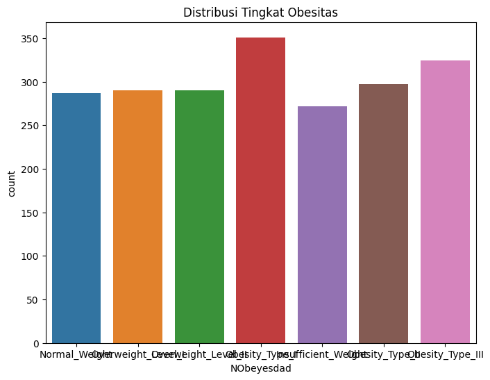

```python
plt.figure(figsize=(8, 6))
sns.countplot(x='NObeyesdad', data=df)
plt.title('Distribusi Tingkat Obesitas')
plt.show()
```

1. Visualisasi korelasi antar variabel numerik dari data

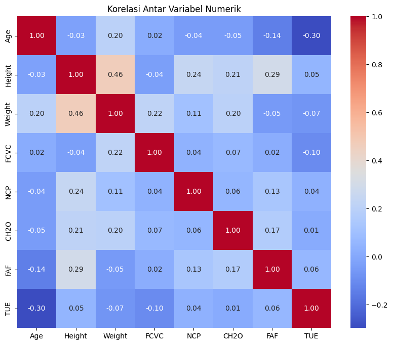

```python
correlation_matrix = df.corr()
plt.figure(figsize=(10, 8))
sns.heatmap(correlation_matrix, annot=True, cmap='coolwarm', fmt=".2f")
plt.title('Korelasi Antar Variabel Numerik')
plt.show()
```

1. Visualisasi beberapa atribut dengan tingkat obesitas

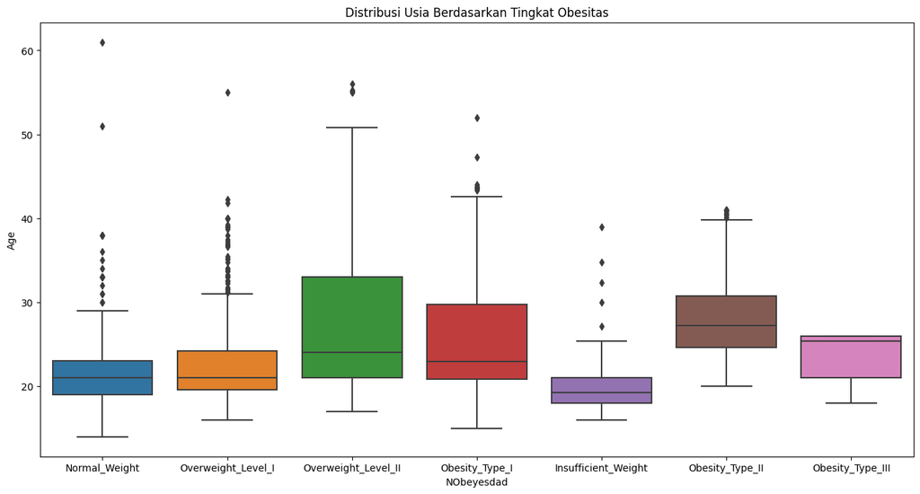

```python
plt.figure(figsize=(16, 8))
sns.boxplot(x='NObeyesdad', y='Age', data=df)
plt.title('Distribusi Usia Berdasarkan Tingkat Obesitas')
plt.show()
```

# **Data Preparation**

1. Mengimpor library yang dibutuhkan

```python
from sklearn.model_selection import train_test_split
from sklearn.preprocessing import StandardScaler
```

1. Penanganan nilai yang hilang : mengganti nilai kosong dengan rata-rata

```python
df.fillna(df.mean(), inplace=True)
```

1. Pemilihan atribut yang relevan sesuai tujuan analisis: dimana di simpan dalam variabel **df_selected**

```python
selected_features = ['Age', 'Height', 'Weight', 'family_history_with_overweight', 'FCVC', 'NCP', 'CH2O', 'FAF', 'TUE', 'MTRANS', 'NObeyesdad']
df_selected = df[selected_features]
```

1. Mengubah variabel kategoris menjadi variabel dummy (one-hot encoding) : bertujuan untuk menghindari multicollinearity

```python
df_selected = pd.get_dummies(df_selected, columns=['family_history_with_overweight', 'MTRANS'], drop_first=True)

print(df_selected)
```

```
            Age    Height      Weight  FCVC  NCP      CH2O       FAF  \
0     21.000000  1.620000   64.000000   2.0  3.0  2.000000  0.000000
1     21.000000  1.520000   56.000000   3.0  3.0  3.000000  3.000000
2     23.000000  1.800000   77.000000   2.0  3.0  2.000000  2.000000
3     27.000000  1.800000   87.000000   3.0  3.0  2.000000  2.000000
4     22.000000  1.780000   89.800000   2.0  1.0  2.000000  0.000000
...         ...       ...         ...   ...  ...       ...       ...
2106  20.976842  1.710730  131.408528   3.0  3.0  1.728139  1.676269
2107  21.982942  1.748584  133.742943   3.0  3.0  2.005130  1.341390
2108  22.524036  1.752206  133.689352   3.0  3.0  2.054193  1.414209
2109  24.361936  1.739450  133.346641   3.0  3.0  2.852339  1.139107
2110  23.664709  1.738836  133.472641   3.0  3.0  2.863513  1.026452

           TUE           NObeyesdad  family_history_with_overweight_yes  \
0     1.000000        Normal_Weight                                   1
```

[output cut: 38 more lines]

1. Normalisasi menggunakan StandardScaler

```python
scaler = StandardScaler()
df_selected[['Age', 'Height', 'Weight', 'FCVC', 'NCP', 'CH2O', 'FAF', 'TUE']] = scaler.fit_transform(df_selected[['Age', 'Height', 'Weight', 'FCVC', 'NCP', 'CH2O', 'FAF', 'TUE']])
```

1. Pemisahan data menjadi dataset pelatihan dan pengujian: Pembagian data dengan 80% untuk pelatihan dan 20% untuk pengujian

```python
X = df_selected.drop('NObeyesdad', axis=1) #memilih features NObeyesdad menjadi atribut yang di analisis
y = df_selected['NObeyesdad']

X_train, X_test, y_train, y_test = train_test_split(X, y, test_size=0.2, random_state=42)
```

1. Menampilkan data testing dan data training

```python
print("Data Training: ")
print(X_train, "\n")
print("Data Testing: ")
print(X_test)
```

```
Data Training:
           Age    Height    Weight      FCVC       NCP      CH2O       FAF  \
162  -0.522124 -0.768388 -1.015318  1.088342  0.404153 -0.013073  1.163820
2001 -0.533953  0.545156  1.796170  1.088342  0.404153  1.435437  0.553418
1435 -0.222692 -0.428400 -0.152388 -2.276674 -1.710184  1.236246 -1.037118
649  -0.390041 -1.218139 -1.617340  1.088342 -1.272151  0.884935  0.104145
1280  0.265136  1.178403  0.743025  1.088342  0.404153  1.387317  0.944295
...        ...       ...       ...       ...       ...       ...       ...
1638  1.257405  0.571152  1.279847  1.027083  0.404153  0.851855 -0.064653
1095 -0.206889  0.185497 -0.187745 -0.785019 -1.229118 -0.991769 -0.143904
1130 -0.208489 -0.553986 -0.251521 -0.785019  0.404153 -0.013073 -1.015273
1294 -0.206889 -0.788028 -0.079743 -0.675077  0.355306  0.004218 -0.187254
860  -0.679742  1.241416 -0.060571  0.996884  0.404153  1.618759  1.674077

           TUE  family_history_with_overweight_yes  MTRANS_Bike  \
```

[output cut: 68 more lines]

1. Menampilkan informasi data setelah preprocessing

```python
print("Info setelah preprocessing:")
print(X_train.info())
```

```
Info setelah preprocessing:
<class 'pandas.core.frame.DataFrame'>
Int64Index: 1688 entries, 162 to 860
Data columns (total 13 columns):
 #   Column                              Non-Null Count  Dtype
---  ------                              --------------  -----
 0   Age                                 1688 non-null   float64
 1   Height                              1688 non-null   float64
 2   Weight                              1688 non-null   float64
 3   FCVC                                1688 non-null   float64
 4   NCP                                 1688 non-null   float64
 5   CH2O                                1688 non-null   float64
 6   FAF                                 1688 non-null   float64
 7   TUE                                 1688 non-null   float64
 8   family_history_with_overweight_yes  1688 non-null   uint8
 9   MTRANS_Bike                         1688 non-null   uint8
 10  MTRANS_Motorbike                    1688 non-null   uint8
 11  MTRANS_Public_Transportation        1688 non-null   uint8
 12  MTRANS_Walking                      1688 non-null   uint8
dtypes: float64(8), uint8(5)
memory usage: 126.9 KB
None
```

1. Menampilkan apakah ada nilai yang hilang

```python
print("Jumlah nilai yang hilang:")
print(X_train.isnull().sum())
```

```
Jumlah nilai yang hilang:
Age                                   0
Height                                0
Weight                                0
FCVC                                  0
NCP                                   0
CH2O                                  0
FAF                                   0
TUE                                   0
family_history_with_overweight_yes    0
MTRANS_Bike                           0
MTRANS_Motorbike                      0
MTRANS_Public_Transportation          0
MTRANS_Walking                        0
dtype: int64
```

# **Modelling**

1. Mengimpor library yang dibutuhkan

```python
from sklearn.svm import SVC
```

1. Membuat model

```python
svm_model = SVC(random_state=42)
```

1. Melatih model dengan dataset pelatihan

```python
svm_model.fit(X_train, y_train)
```

```
SVC(random_state=42)
```

1. Validasi model dengan menggunakan dataset testing

```python
y_pred_svm = svm_model.predict(X_test)

print(y_pred_svm)
```

```
['Insufficient_Weight' 'Obesity_Type_III' 'Insufficient_Weight'
 'Insufficient_Weight' 'Overweight_Level_I' 'Insufficient_Weight'
 'Obesity_Type_II' 'Overweight_Level_I' 'Obesity_Type_I'
 'Insufficient_Weight' 'Obesity_Type_I' 'Obesity_Type_III'
 'Obesity_Type_II' 'Obesity_Type_II' 'Obesity_Type_III'
 'Overweight_Level_II' 'Obesity_Type_III' 'Obesity_Type_II'
 'Obesity_Type_I' 'Obesity_Type_I' 'Obesity_Type_I' 'Overweight_Level_II'
 'Obesity_Type_III' 'Obesity_Type_I' 'Normal_Weight' 'Overweight_Level_II'
 'Overweight_Level_II' 'Obesity_Type_III' 'Obesity_Type_III'
 'Insufficient_Weight' 'Obesity_Type_III' 'Overweight_Level_I'
 'Overweight_Level_II' 'Normal_Weight' 'Insufficient_Weight'
 'Obesity_Type_III' 'Obesity_Type_I' 'Normal_Weight' 'Normal_Weight'
 'Normal_Weight' 'Normal_Weight' 'Obesity_Type_II' 'Overweight_Level_I'
 'Normal_Weight' 'Overweight_Level_I' 'Insufficient_Weight'
 'Obesity_Type_II' 'Normal_Weight' 'Obesity_Type_I' 'Obesity_Type_II'
 'Normal_Weight' 'Normal_Weight' 'Normal_Weight' 'Overweight_Level_I'
 'Insufficient_Weight' 'Overweight_Level_II' 'Obesity_Type_II'
 'Obesity_Type_II' 'Overweight_Level_I' 'Obesity_Type_II' 'Normal_Weight'
 'Obesity_Type_III' 'Overweight_Level_II' 'Insufficient_Weight'
 'Obesity_Type_II' 'Obesity_Type_I' 'Overweight_Level_I'
 'Obesity_Type_III' 'Insufficient_Weight' 'Normal_Weight'
 'Overweight_Level_II' 'Overweight_Level_II' 'Insufficient_Weight'
 'Insufficient_Weight' 'Overweight_Level_I' 'Obesity_Type_II'
 'Obesity_Type_II' 'Normal_Weight' 'Obesity_Type_III' 'Obesity_Type_II'
 'Normal_Weight' 'Obesity_Type_I' 'Obesity_Type_II' 'Obesity_Type_II'
 'Obesity_Type_I' 'Obesity_Type_I' 'Overweight_Level_II'
 'Overweight_Level_II' 'Normal_Weight' 'Overweight_Level_I'
 'Overweight_Level_I' 'Obesity_Type_II' 'Insufficient_Weight'
 'Overweight_Level_I' 'Obesity_Type_I' 'Insufficient_Weight'
 'Normal_Weight' 'Obesity_Type_I' 'Overweight_Level_I' 'Obesity_Type_II'
 'Obesity_Type_I' 'Obesity_Type_I' 'Obesity_Type_III' 'Obesity_Type_I'
 'Overweight_Level_II' 'Obesity_Type_I' 'Normal_Weight' 'Obesity_Type_III'
 'Obesity_Type_III' 'Obesity_Type_II' 'Obesity_Type_I' 'Normal_Weight'
 'Obesity_Type_I' 'Normal_Weight' 'Insufficient_Weight' 'Obesity_Type_I'
 'Obesity_Type_I' 'Obesity_Type_II' 'Overweight_Level_II' 'Normal_Weight'
 'Obesity_Type_III' 'Obesity_Type_II' 'Obesity_Type_I'
 'Overweight_Level_II' 'Normal_Weight' 'Obesity_Type_II' 'Obesity_Type_I'
 'Obesity_Type_I' 'Obesity_Type_III' 'Obesity_Type_II' 'Obesity_Type_III'
 'Obesity_Type_II' 'Normal_Weight' 'Obesity_Type_I' 'Overweight_Level_II'
 'Obesity_Type_III' 'Insufficient_Weight' 'Obesity_Type_III'
```

[output cut: 73 more lines]

```
 'Obesity_Type_I' 'Overweight_Level_II' 'Insufficient_Weight'
 'Normal_Weight' 'Obesity_Type_I' 'Obesity_Type_I' 'Obesity_Type_I'
 'Overweight_Level_II' 'Normal_Weight' 'Normal_Weight' 'Obesity_Type_III'
 'Overweight_Level_I' 'Obesity_Type_III' 'Obesity_Type_III'
 'Normal_Weight' 'Obesity_Type_I' 'Obesity_Type_II' 'Normal_Weight'
 'Obesity_Type_III' 'Overweight_Level_II' 'Obesity_Type_II'
 'Overweight_Level_I' 'Insufficient_Weight' 'Obesity_Type_III'
 'Overweight_Level_I' 'Obesity_Type_III' 'Normal_Weight'
 'Insufficient_Weight' 'Normal_Weight' 'Overweight_Level_I'
 'Obesity_Type_I' 'Normal_Weight' 'Insufficient_Weight' 'Obesity_Type_III'
 'Normal_Weight' 'Obesity_Type_III' 'Overweight_Level_II'
 'Overweight_Level_I' 'Overweight_Level_I' 'Overweight_Level_I'
 'Obesity_Type_III' 'Insufficient_Weight' 'Normal_Weight' 'Obesity_Type_I'
 'Overweight_Level_I' 'Obesity_Type_II' 'Insufficient_Weight'
 'Obesity_Type_II' 'Overweight_Level_I']
```

# **Evaluation**

1. Import library yang dibutuhkan yaitu menggunakan function dari library sklearn yang terdiri dari accuracy score dan classification report.

```python
from sklearn.metrics import accuracy_score, classification_report
```

1. Evaluasi menggunakan matriks yang relevan

```python
akurasi_svm = accuracy_score(y_test, y_pred_svm)
laporan_klasifikasi_svm = classification_report(y_test, y_pred_svm)
```

1. Tampilkan hasil evaluasi

```python
print(f"Akurasi SVM: {akurasi_svm}")
print("\nLaporan Klasifikasi SVM:\n", laporan_klasifikasi_svm)
```

```
Akurasi SVM: 0.8888888888888888

Laporan Klasifikasi SVM:
                      precision    recall  f1-score   support

Insufficient_Weight       0.93      0.96      0.95        56
      Normal_Weight       0.83      0.81      0.82        62
     Obesity_Type_I       0.91      0.96      0.94        78
    Obesity_Type_II       0.97      0.98      0.97        58
   Obesity_Type_III       1.00      1.00      1.00        63
 Overweight_Level_I       0.74      0.75      0.74        56
Overweight_Level_II       0.80      0.70      0.74        50

           accuracy                           0.89       423
          macro avg       0.88      0.88      0.88       423
       weighted avg       0.89      0.89      0.89       423
```

# **Implementation**

Implementasi hasil analisis ke dalam strategi bisnis dapat melibatkan beberapa langkah konkret untuk meningkatkan manfaat dari model klasifikasi. Berikut adalah beberapa strategi yang dapat diambil:

- **Penyesuaian Model**:
  - Berdasarkan laporan klasifikasi, identifikasi kelas-kelas yang memiliki performa rendah **(precision, recall, atau f1-score yang rendah)**. Maka Lakukan penyesuaian model, seperti *tuning parameter*, penambahan fitur yang relevan, atau penanganan ketidakseimbangan kelas, untuk meningkatkan performa kelas-kelas tersebut.
- **Validasi Tambahan**:
  - Lakukan validasi tambahan terhadap model menggunakan dataset yang berbeda, jika tersedia, untuk memastikan generalisasi yang baik.
- **Interpretasi Model**:
  - Terapkan teknik interpretasi model untuk memahami faktor apa yang mempengaruhi prediksi model. Hal ini dapat membantu dalam mendapatkan wawasan tambahan yang dapat digunakan untuk merancang intervensi atau rekomendasi yang lebih efektif.
- **Kerjasama dengan Ahli Kesehatan**:
  - Melibatkan ahli kesehatan untuk mengevaluasi hasil model dari perspektif medis dan nutrisi. Mereka dapat memberikan wawasan tambahan untuk meningkatkan validitas klinis model.
- **Edukasi Pengguna**:
  - Edukasi pengguna model (misalnya, praktisi kesehatan atau individu yang tertarik) tentang cara memahami dan menginterpretasi hasil model. Hal ini dapat membantu mereka membuat keputusan yang lebih baik berdasarkan prediksi model.
- **Pengembangan Aplikasi atau Platform**:
  - Jika memungkinkan, pertimbangkan pengembangan aplikasi atau platform yang memanfaatkan model ini untuk memberikan rekomendasi berdasarkan input pengguna terkini. Aplikasi semacam itu dapat memberikan layanan yang lebih terpersonalisasi.

# **Reference**

- https://archive.ics.uci.edu/dataset/544/estimation+of+obesity+levels+based+on+eating+habits+and+physical+condition
- https://en.wikipedia.org/wiki/Support_vector_machine
- https://scikit-learn.org/stable/modules/svm.html
- https://medium.com/@samsudiney/penjelasan-sederhana-tentang-apa-itu-svm-149fec72bd02
- https://www.w3schools.com/python/matplotlib_pyplot.asp
- https://www.w3schools.com/python/numpy/numpy_random_seaborn.asp
- https://scikit-learn.org/stable/modules/svm.html
- https://scikit-learn.org/stable/modules/model_evaluation.html